# Time Series Project - Main Code Notebook

This notebook includes all code related to the analyses described in the report, including exploratory checks and validation steps that use data beyond the main dataset submitted for the project.

- Some code segments rely on additional data files, which are not part of the core submission, but are available in our GitHub repository at https://github.com/sinitsky96/Time-Series-Project for full reproducibility.
- All such segments are clearly commented in the code and are optional for running the main analysis.

The primary dataset used for the project is named [pollution_and_new_cars_unified.csv], and all core results and models are based on it.

```python
import pandas as pd
import numpy as np
from statsmodels.tsa.seasonal import seasonal_decompose
import matplotlib.pyplot as plt
import seaborn as sns
import matplotlib.dates as mdates
import os
from statsmodels.graphics import tsaplots
from statsmodels.tsa.statespace.sarimax import SARIMAX
from prophet import Prophet
from prophet.plot import plot_components
from sklearn.metrics import mean_squared_error, mean_absolute_error
from datetime import datetime
from statsmodels.tsa.holtwinters import SimpleExpSmoothing
from statsmodels.tsa.holtwinters import ExponentialSmoothing

sns.set_style("darkgrid")
```

```python
import warnings
from statsmodels.tools.sm_exceptions import ValueWarning

# Suppress specific statsmodels warnings about frequency
warnings.filterwarnings('ignore', 'No frequency information was provided')
warnings.filterwarnings('ignore', 'No supported index is available')
warnings.filterwarnings('ignore', category=UserWarning)
warnings.filterwarnings('ignore', category=ValueWarning)
warnings.filterwarnings('ignore', category=FutureWarning)
```

## Part 1 - Data EDA

```python
df = pd.read_csv("data/pollution_and_new_cars_unified.csv")
```

```python
# split the unified dataset to data on air pollution and data on cars registration
df['date'] = pd.to_datetime(df['date'], format = "%d/%m/%Y")
co_levels = df.drop("car_num", axis = 1)
co_levels = pd.melt(co_levels, id_vars='date', var_name='station', value_name='CO')
cars = df.loc[:, ['date','car_num']].set_index("date")
```

### Missing Values Analysis

For the missing data part we use daily data instead of the half-monthly aggregation. The data can be found on our github repository (link attached above)

```python
daily_co = pd.read_csv("data/co_daily_clean.csv")
daily_co['date'] = pd.to_datetime(daily_co['date'], format = "%d/%m/%Y")
```

```python
# aggregate missing values by year
nan_by_year_station = daily_co.groupby([daily_co['date'].dt.year,
                      'station'])['CO'].apply(lambda x: x.isna().sum()).reset_index(name = "NaN Count")
nan_by_year_mean = nan_by_year_station.groupby("date")["NaN Count"].mean().reset_index(name = "NaN Count")

# aggregate missing values each month
nan_by_date = (
    daily_co.groupby([daily_co['date'].dt.year, daily_co['date'].dt.month, 'station'])['CO']
    .apply(lambda x: x.isna().sum())
    .rename_axis(['Year','Month', 'station'])
    .reset_index(name="NaN Count")
)
nan_by_date['date'] = pd.to_datetime(nan_by_date[['Year','Month']].assign(day=1))
nan_by_date.drop(["Year","Month"], axis=1, inplace=True)

nan_by_date_mean = (
  nan_by_date.groupby([nan_by_date['date'].dt.year, nan_by_date['date'].dt.month])['NaN Count']
 .mean()
 .rename_axis(['Year','Month'])
 .reset_index(name="NaN Count")
)
nan_by_date_mean['date'] = pd.to_datetime(nan_by_date_mean[['Year','Month']].assign(day=1))
nan_by_date_mean.drop(["Year","Month"], axis=1, inplace=True)
```

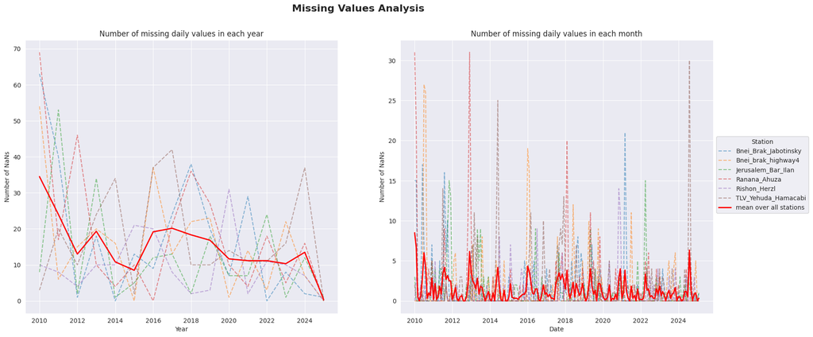

```python
#plot both graphs

fig, axes = plt.subplots(nrows=1, ncols=2, figsize=(20, 8))

sns.lineplot(ax = axes[0], data = nan_by_year_station, x='date', y='NaN Count', hue='station', alpha = 0.5, linestyle='--')
sns.lineplot(ax = axes[0], data = nan_by_year_mean, x = 'date', y='NaN Count', color = 'red', linewidth = 2, label="mean over all stations")
axes[0].set_xlabel("Year")
axes[0].set_ylabel("Number of NaNs")
axes[0].set_title("Number of missing daily values in each year")

sns.lineplot(ax = axes[1], data = nan_by_date, x='date', y='NaN Count', hue='station',  alpha = 0.5, linestyle='--')
sns.lineplot(ax = axes[1], data = nan_by_date_mean, x='date', y='NaN Count', color = 'red', linewidth = 2, label="mean over all stations")
axes[1].set_xlabel("Date")
axes[1].set_ylabel("Number of NaNs")
axes[1].set_title("Number of missing daily values in each month")

handles, labels = axes[1].get_legend_handles_labels()
axes[0].legend_.remove()
axes[1].legend_.remove()
fig.legend(handles, labels, title="Station", loc="center left", bbox_to_anchor=(0.9, 0.5))

fig.suptitle("Missing Values Analysis", fontsize=16, fontweight="bold")
# plt.savefig("visualizations/missing_values_analysis.png", dpi=300, bbox_inches='tight')

plt.show()
```

## Part 2 - Model Fitting

```python
# selecting data from 2012 onward to account for changepoint
co_levels.set_index('date', inplace=True)
co_levels_2012 = co_levels[co_levels.index >= '2012-01-01']
```

### Model Fitting With SARIMA

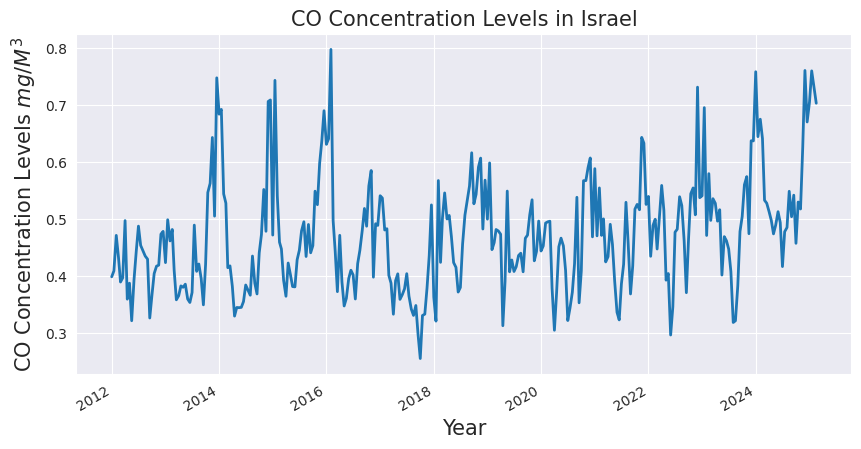

```python
# Plotting time-series from 2012
co_mean_2012 = (co_levels_2012.groupby(co_levels_2012.index)["CO"]
      .mean()
      .reset_index()
      .set_index('date'))
co_mean_2012.plot(figsize=(10,5), linewidth=2, fontsize=10)
plt.title("CO Concentration Levels in Israel",fontsize=15)
plt.xlabel('Year', fontsize=15)
plt.ylabel('CO Concentration Levels $mg/M^3$', fontsize=15)
plt.legend().set_visible(False);
```

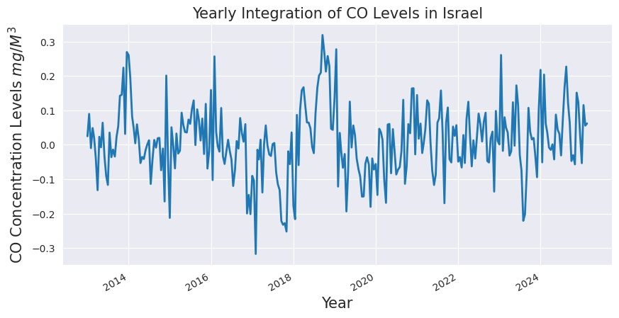

```python
year_integration = co_mean_2012.diff(periods=24)
year_integration = year_integration.dropna()
year_integration.plot(figsize=(10,5), linewidth=2, fontsize=10)
plt.title("Yearly Integration of CO Levels in Israel", fontsize=15)
plt.xlabel('Year', fontsize=15)
plt.ylabel('CO Concentration Levels $mg/M^3$', fontsize=15)
plt.legend().set_visible(False);
```

#### Correlograms Analysis

```
Significant PACF lags (exceeding the ±0.117 threshold):
At lag 1 (approx. 15 days 00:00:00 offset): PACF = 0.4313 exceeds ±0.1170
At lag 2 (approx. 30 days 00:00:00 offset): PACF = 0.1811 exceeds ±0.1170
At lag 3 (approx. 45 days 00:00:00 offset): PACF = 0.1262 exceeds ±0.1170
At lag 24 (approx. 360 days 00:00:00 offset): PACF = -0.5311 exceeds ±0.1170
At lag 25 (approx. 375 days 00:00:00 offset): PACF = 0.2169 exceeds ±0.1170
At lag 34 (approx. 510 days 00:00:00 offset): PACF = 0.1304 exceeds ±0.1170
```

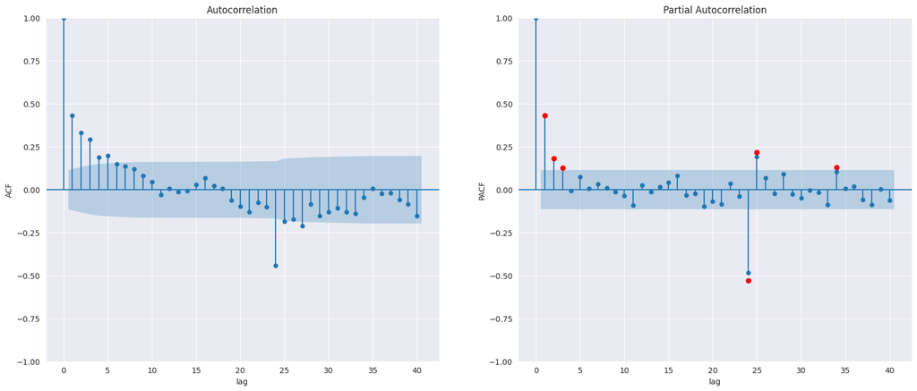

```python
# Plot ACF for year-integration series
fig, axes = plt.subplots(nrows=1, ncols=2, figsize=(20, 8))
tsaplots.plot_acf(year_integration, lags=40, ax=axes[0])
axes[0].set_xlabel("lag")
axes[0].set_ylabel("ACF")

# Plot PACF with colored significant points
pacf_plot = tsaplots.plot_pacf(year_integration, lags=40, ax=axes[1])
axes[1].set_xlabel("lag")
axes[1].set_ylabel("PACF")

# Get the PACF values and confidence intervals
pacf_values = tsaplots.pacf(year_integration['CO'], nlags=40)
confidence_interval = 2 / np.sqrt(len(year_integration))

# Print a header for insights
print("Significant PACF lags (exceeding the ±{:.3f} threshold):".format(confidence_interval))

# Optionally, compute the median time difference between observations.
# This assumes that your datetime index has approximately regular frequency.
time_delta = year_integration.index.to_series().diff().median()

# Color points and print insights where PACF values exceed the confidence limits.
for i, value in enumerate(pacf_values):
    if i > 0 and abs(value) > confidence_interval:  # Skip lag 0
        # Compute an estimated time offset for the lag.
        time_offset = i * time_delta
        # Print textual insight
        print(f"At lag {i} (approx. {time_offset} offset): PACF = {value:.4f} exceeds ±{confidence_interval:.4f}")
        # Highlight the significant lag on the PACF plot
        axes[1].plot(i, value, 'ro')
```

**ACF and PACF analysis:**

1. **Short-term dependency:** The PACF plot displays a strong spike at lag 1, with modest but significant correlations at lags 2 and 3. This suggests an autoregressive (AR) component of order 1–3. The ACF plot also shows strong spikes at lags 1–3, supporting the inclusion of a moving average (MA) component with order 1–3. Minor spikes at lags 4–5 slightly exceed the confidence band but are likely due to half-monthly noise.
2. **Seasonal Structure:** A clear seasonal pattern appears at lags 24–25, corresponding to an annual cycle. Both ACF and PACF show significant spikes at lags 24 and 25. This pattern is consistent with a seasonal MA(1) component.

**Model considerations:** Based on this analysis and aiming for parsimony, candidate SARIMA specifications include:

- **SARIMA(1–3,0,1–3)(0,1,1)[24]:** — capturing short-term AR and MA effects with seasonal MA. Seasonal differencing is included to address the annual pattern

```python
# Split the data into train and test sets (80% training, 20% testing)
train_size = int(len(co_mean_2012) * 0.8)
train = co_mean_2012.iloc[:train_size]
test = co_mean_2012.iloc[train_size:]
print("Train shape:", train.shape)
print("Test shape:", test.shape)
```

```
Train shape: (252, 1)
Test shape: (64, 1)
```

```
Model Comparison:
                          Order       AIC       BIC    RMSE     MAE
0  SARIMA(1, 0, 1)(0, 1, 1, 24) -539.6448 -525.9274  0.1473  0.0905
3  SARIMA(1, 0, 2)(0, 1, 1, 24) -537.7480 -520.6013  0.1472  0.0904
1  SARIMA(2, 0, 1)(0, 1, 1, 24) -537.7409 -520.5942  0.1473  0.0904
2  SARIMA(3, 0, 1)(0, 1, 1, 24) -536.1479 -515.5718  0.1472  0.0904
6  SARIMA(1, 0, 3)(0, 1, 1, 24) -536.0755 -515.4994  0.1472  0.0903
4  SARIMA(2, 0, 2)(0, 1, 1, 24) -535.7383 -515.1623  0.1473  0.0904
7  SARIMA(2, 0, 3)(0, 1, 1, 24) -534.1995 -510.1941  0.1472  0.0904
5  SARIMA(3, 0, 2)(0, 1, 1, 24) -534.0424 -510.0370  0.1472  0.0904
8  SARIMA(3, 0, 3)(0, 1, 1, 24) -532.3755 -504.9407  0.1472  0.0904
```

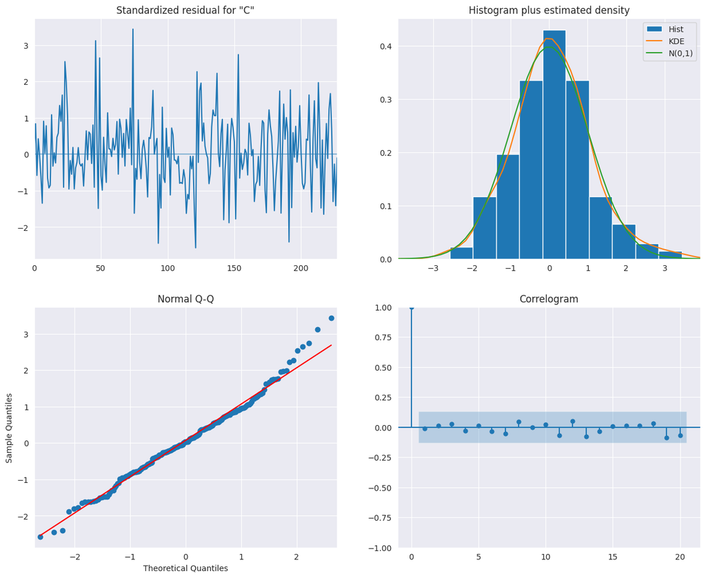

```python
# ACF and PACF analysis:
# - Short-term dependency:
#   - PACF: Strong spike at lag 1, modest but significant at lags 2–3 → suggests AR order 1–3
#   - ACF: Strong spikes at lags 1–3 → suggests MA order 1–3
#   - Minor spikes at lags 4–5 likely reflect half-monthly noise
# - Seasonal structure:
#   - Significant negative spike at lag 24 and positive at lag 25 in both ACF and PACF
#   - Suggests seasonal MA(1) component (annual seasonality)

models = []

for q in range(1,4):
    for p in range(1,4):
        models.append(SARIMAX(train, order=(p,0,q), seasonal_order = (0,1,1,24)))


model_results = []
for model in models:
    results = model.fit(disp=False)
    # Get residuals for RMSE and MAE
    residuals = results.resid
    rmse = np.sqrt(np.mean(residuals**2))
    mae = np.mean(np.abs(residuals))

    model_results.append({
        'model': model,
        'order': model.order,
        'seasonal_order': model.seasonal_order,
        'aic': results.aic,
        'bic': results.bic,
        'rmse': rmse,
        'mae': mae,
        'results': results
    })

# Create a comparison DataFrame
comparison_df = pd.DataFrame([
    {
        'Order': f"SARIMA{res['order']}{res['seasonal_order']}",
        'AIC': res['aic'],
        'BIC': res['bic'],
        'RMSE': res['rmse'],
        'MAE': res['mae']
    }
    for res in model_results
])

print("Model Comparison:")
print(comparison_df.sort_values('BIC'))

# Store the best model based on the lowest BIC and display its diagnostics
best_model = min(model_results, key=lambda x: x['bic'])
best_model['results'].plot_diagnostics(lags=20, figsize=(15, 12))
# plt.savefig("sarima_model_diagnostics.png")
plt.show()
```

```python
# print best model (SARIMA(1,0,1)(0,1,1)_24) summary
models[0].fit().summary()
```

SARIMAX Results

| Dep. Variable: | CO | No. Observations: | 252 |
| --- | --- | --- | --- |
| Model: | SARIMAX(1, 0, 1)x(0, 1, 1, 24) | Log Likelihood | 273.822 |
| Date: | Sun, 06 Apr 2025 | AIC | -539.645 |
| Time: | 10:43:15 | BIC | -525.927 |
| Sample: | 0 | HQIC | -534.110 |
|  | - 252 |  |  |
| Covariance Type: | opg |  |  |

|  | coef | std err | z | P>\|z\| | [0.025 | 0.975] |
| --- | --- | --- | --- | --- | --- | --- |
| ar.L1 | 0.7551 | 0.078 | 9.689 | 0.000 | 0.602 | 0.908 |
| ma.L1 | -0.3366 | 0.118 | -2.854 | 0.004 | -0.568 | -0.105 |
| ma.S.L24 | -0.8947 | 0.130 | -6.896 | 0.000 | -1.149 | -0.640 |
| sigma2 | 0.0045 | 0.001 | 8.240 | 0.000 | 0.003 | 0.006 |

| Ljung-Box (L1) (Q): | 0.02 | Jarque-Bera (JB): | 6.43 |
| --- | --- | --- | --- |
| Prob(Q): | 0.88 | Prob(JB): | 0.04 |
| Heteroskedasticity (H): | 1.01 | Skew: | 0.28 |
| Prob(H) (two-sided): | 0.98 | Kurtosis: | 3.61 |

Warnings:  
[1] Covariance matrix calculated using the outer product of gradients (complex-step).

#### SARIMA Model Analysis for CO Levels in Israel

##### Model Diagnostics

- Residuals are approximately normally distributed, as seen in the histogram and Q-Q plot.
- No significant autocorrelation remains, based on the residual ACF/PACF plots.
- The Ljung-Box test fails to reject the null hypothesis, supporting the conclusion that residuals are uncorrelated.
- Standardized residuals show overall stable variance.
- Some local patterns between 2012–2018 may reflect a structural change or small-sample effect.

Overall, the model captures short-term dynamics and seasonal structure well.

#### Monthly Data Fitting

As an additional check, we fit a SARIMA model to the monthly-aggregated data. This analysis is not part of the main time-series modeling, but rather aims to demonstrate that the half-monthly aggregation used earlier introduces noise into the series. By comparing model diagnostics across aggregation levels, we highlight how finer time scales may distort temporal structure.

```python
# compatison to Monthly aggregated data (based on data available on github)
co_monthly = daily_co.groupby([daily_co['date'].dt.year.rename('year'),
                         daily_co['date'].dt.month.rename('month'),
                         'station'])['CO'].mean().reset_index()

co_monthly['date'] = pd.to_datetime(co_monthly[['year','month']].assign(day=1))
co_monthly = co_monthly.drop(["year","month"], axis =1)

# remove records prior to 2012
co_monthly.set_index('date', inplace=True)
co_monthly_2012 = co_monthly[co_monthly.index >= '2012-01-01']

# get mean over all stations
co_monthly_mean = (co_monthly_2012.groupby(co_monthly_2012.index)["CO"]
                   .mean()
                   .reset_index()
                   .set_index('date'))

# remove yearly seasonality trend with 12-months differencing
year_integration_monthly = co_monthly_mean.diff(periods=12).dropna()
```

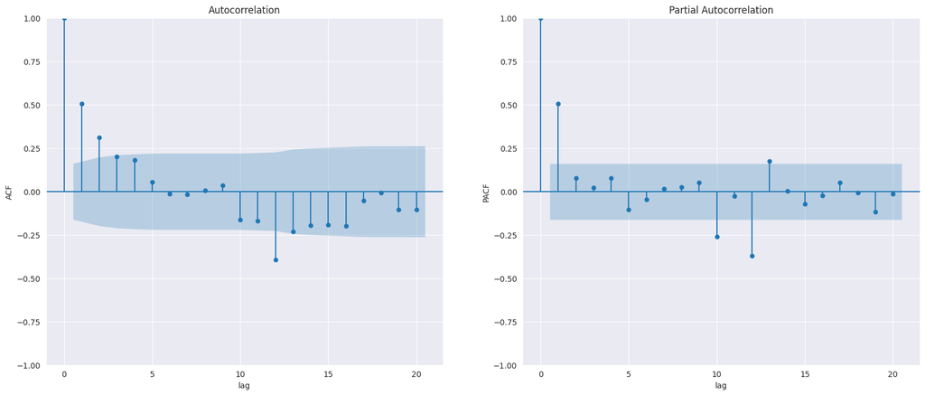

```python
# plot correlograms for monthly data
fig, axes = plt.subplots(nrows=1, ncols=2, figsize=(20, 8))
tsaplots.plot_acf(year_integration_monthly, lags=20, ax=axes[0])
axes[0].set_xlabel("lag")
axes[0].set_ylabel("ACF")

# Plot PACF with colored significant points
pacf_plot = tsaplots.plot_pacf(year_integration_monthly, lags=20, ax=axes[1])
axes[1].set_xlabel("lag")
axes[1].set_ylabel("PACF")

plt.show()

# # Code for saving relevant figure
# tsaplots.plot_acf(year_integration_monthly, lags=20)
# plt.xlabel("lag")
# plt.ylabel("ACF")
# plt.savefig("acf_monthly.png", dpi=300, bbox_inches='tight')
# plt.show()
```

- the ACF plot for monthly data shows only two spikes above the confidence band at lag 1 and 2 (instead of 5 at the half-monthly data), with the second much less prominent
- The PACF shows one significant skipe at lag 1
- We can observe seasonal structure with both ACF and PACF show significant spikes at lags 12.

Accordingly, we will check SARIMA(1,0,1–2)(0-1,1,1)_12

```python
monthly_train = co_monthly_mean.iloc[:int(len(co_monthly_mean) * 0.8)]
monthly_test = co_monthly_mean.iloc[int(len(co_monthly_mean) * 0.8):]

monthly_models = [SARIMAX(monthly_train, order=(1,0,1),
                          seasonal_order = (0,1,1,12)),
                  SARIMAX(monthly_train, order=(1,0,2),
                          seasonal_order = (0,1,1,12)),
                  SARIMAX(monthly_train, order=(1,0,1),
                          seasonal_order = (1,1,1,12)),
                  SARIMAX(monthly_train, order=(1,0,2),
                          seasonal_order = (1,1,1,12))]

monthly_model_results = []
for model in monthly_models:
    results = model.fit(disp=False)
    # Get residuals for RMSE and MAE
    residuals = results.resid
    rmse = np.sqrt(np.mean(residuals**2))
    mae = np.mean(np.abs(residuals))

    monthly_model_results.append({
        'model': model,
        'order': model.order,
        'seasonal_order': model.seasonal_order,
        'aic': results.aic,
        'bic': results.bic,
        'rmse': rmse,
        'mae': mae,
        'results': results
    })

# Create a comparison DataFrame
monthly_comparison_df = pd.DataFrame([
    {
        'Order': f"SARIMA{res['order']}{res['seasonal_order']}",
        'AIC': res['aic'],
        'BIC': res['bic'],
        'RMSE': res['rmse'],
        'MAE': res['mae']
    }
    for res in monthly_model_results
])

print("Model Comparison:")
print(monthly_comparison_df.sort_values('BIC'))
```

```
Model Comparison:
                          Order       AIC       BIC    RMSE     MAE
0  SARIMA(1, 0, 1)(0, 1, 1, 12) -302.2377 -291.2929  0.1425  0.0830
2  SARIMA(1, 0, 1)(1, 1, 1, 12) -301.0358 -287.3548  0.1424  0.0832
1  SARIMA(1, 0, 2)(0, 1, 1, 12) -301.0064 -287.3254  0.1424  0.0829
3  SARIMA(1, 0, 2)(1, 1, 1, 12) -299.8906 -283.4735  0.1423  0.0830
```

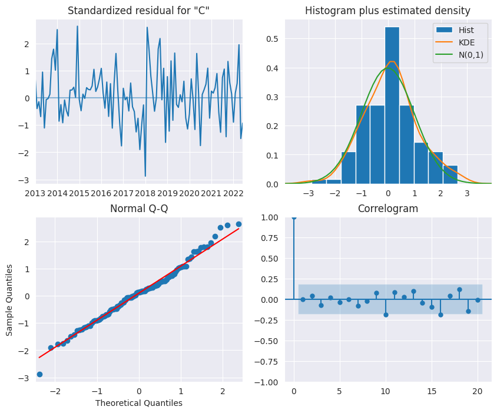

```python
best_monthly_model = min(monthly_model_results, key=lambda x: x['bic'])
best_monthly_model['results'].plot_diagnostics(lags=20, figsize=(10, 8))
plt.show()
```

The best-fitting SARIMA model remains SARIMA(1,0,1) (0,1,1)_12, consistent with the model selected for the half-monthly data.

### Model Fitting With Prophet

```python
import logging
logging.getLogger("cmdstanpy").setLevel(logging.WARNING)
logging.getLogger('cmdstanpy').setLevel(logging.CRITICAL)
logging.getLogger('prophet').setLevel(logging.CRITICAL)
logging.getLogger('prophet.models').setLevel(logging.CRITICAL)
```

```python
from prophet.diagnostics import cross_validation, performance_metrics

# Apply cross-validation to find best changepoint prior scale

# Convert the training data to Prophet format
prophet_df = train.reset_index()
prophet_df.columns = ['ds', 'y']  # Prophet requires these specific column names


def cross_validation_changepoint_prior_scale(df, weekly_seasonality=False):
  """
  Perform cross-validation to find the best changepoint_prior_scale value.
  @ df - The training data.
  @ weekly_seasonality - Whether to include weekly seasonality.
  """

  # Range of changepoint_prior_scale Values to Compare
  cps_values = [0.001, 0.01, 0.05, 0.1, 0.5]

  # Collect performance metrics for each CPS value
  all_perf = []

  for cps in cps_values:
    model = Prophet(
        yearly_seasonality=True,
        weekly_seasonality=weekly_seasonality,
        daily_seasonality=False,
        changepoint_prior_scale=cps,
        changepoint_range=1.0
    )
    model.fit(df)

    # Cross-Validation Setup
    df_cv = cross_validation(
        model=model,
        initial='1460 days',
        period='180 days',
        horizon='365 days',
        parallel='processes'
    )

    # Compute Performance Metrics
    df_perf = performance_metrics(df_cv)
    df_perf['changepoint_prior_scale'] = cps

    all_perf.append(df_perf)

  df_perf_all = pd.concat(all_perf)
  return df_perf_all.groupby('changepoint_prior_scale', as_index=False).mean()
```

```python
cross_validation_changepoint_prior_scale(prophet_df)
```

|  | changepoint_prior_scale | horizon | mse | rmse | mae | mape | mdape | smape | coverage |
| --- | --- | --- | --- | --- | --- | --- | --- | --- | --- |
| 0 | 0.001 | 202 days 21:20:48.241206030 | 0.0090 | 0.0944 | 0.0750 | 0.1775 | 0.1373 | 0.1627 | 0.6622 |
| 1 | 0.010 | 202 days 21:20:48.241206030 | 0.0089 | 0.0941 | 0.0747 | 0.1757 | 0.1409 | 0.1622 | 0.6680 |
| 2 | 0.050 | 202 days 21:20:48.241206030 | 0.0109 | 0.1039 | 0.0820 | 0.1870 | 0.1495 | 0.1832 | 0.6106 |
| 3 | 0.100 | 202 days 21:20:48.241206030 | 0.0122 | 0.1098 | 0.0861 | 0.1933 | 0.1626 | 0.1950 | 0.5655 |
| 4 | 0.500 | 202 days 21:20:48.241206030 | 0.0187 | 0.1342 | 0.1031 | 0.2267 | 0.1812 | 0.2346 | 0.5028 |

The 0.01 prior scale choice minimized MSE, RMSE, MAE, MAPE and maximizes coverage.

```
Model Comparison:
      SARIMA  Prophet
RMSE  0.1473   0.0722
MAE   0.0905   0.0560
```

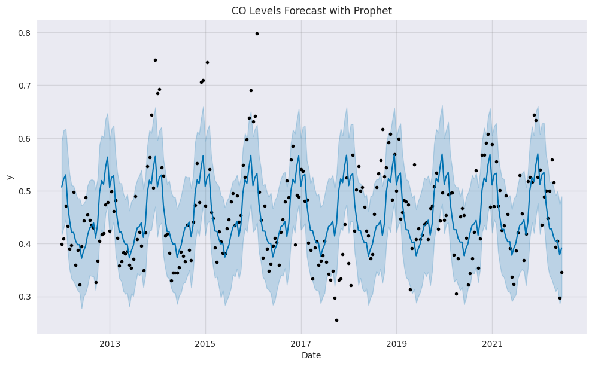

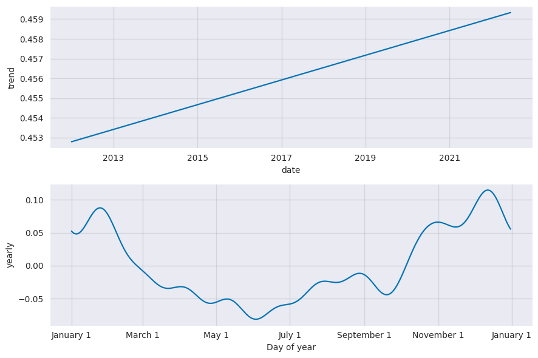

```python
# Fit Prophet model on training data
model_prophet = Prophet(yearly_seasonality=True,
                        weekly_seasonality=False,
                        daily_seasonality=False,
                       changepoint_prior_scale=0.01,
                       changepoint_range=1.0)
model_prophet.fit(prophet_df)

# Forecast for a number of periods equal to the length of the test set
future_dates = model_prophet.make_future_dataframe(periods=len(test),
                                                  freq='15D')
forecast_prophet = model_prophet.predict(future_dates)

# Calculate metrics for both models
prophet_fitted = forecast_prophet.loc[forecast_prophet['ds'].isin(prophet_df['ds']), 'yhat']
prophet_actual = prophet_df['y']


prophet_metrics = {
    'RMSE': np.sqrt(mean_squared_error(prophet_actual, prophet_fitted)),
    'MAE': mean_absolute_error(prophet_actual, prophet_fitted)
}

# SARIMA metrics (from best_model)
sarima_metrics = {
    'RMSE': best_model['rmse'],
    'MAE': best_model['mae']
}

# Create comparison DataFrame
comparison_df = pd.DataFrame({
    'SARIMA': sarima_metrics,
    'Prophet': prophet_metrics
})

print("\nModel Comparison:")
print(comparison_df)

# Plot Prophet forecast and components
fig1 = model_prophet.plot(forecast_prophet[:train_size])
plt.xlabel('Date')
plt.title('CO Levels Forecast with Prophet')
# plt.savefig("prophet_fit.png", dpi=300, bbox_inches="tight")
plt.show()

fig2 = model_prophet.plot_components(forecast_prophet[:train_size])
fig2.axes[0].set_xlabel("date")
# plt.savefig("prophet_decomposition.png", dpi=300, bbox_inches="tight")
plt.show()
```

#### Rationale for Using Prophet

After extensive time series analysis on the CO levels in Israel, we observed the following:

- **Short-Term Dependencies:**  
  The PACF plot shows a dominant AR(1) effect (lag 1, approx. 15 days) along with secondary influences at lags 2 and 3. This indicates that the most recent observations significantly impact the current values.
- **Seasonal Structure:**  
  A clear annual cycle is evident, with a marked negative spike at lag 24 (approximately 360 days) and a positive spike at lag 25 (around 375 days). This seasonal pattern is intrinsic to the data.

Given these insights, we chose to complement our SARIMA and Kalman-Filters models with Prophet for several key reasons:

1. **Automatic Seasonality Detection:**  
   Prophet is specifically designed to automatically capture seasonal patterns—such as the yearly cycle in our data—without requiring manual specification of complex seasonal parameters. It achieves this by modeling seasonality using a Fourier series, which allows for flexible and smooth representations of periodic effects.
2. **Component Decomposition:**  
   Prophet provides a clear breakdown of the time series into trend, seasonal, and residual components. This decomposition is valuable for both diagnostics and interpretation, much like what our PACF and ACF analyses reveal.
3. **Robustness to Data Irregularities:**  
   Prophet handles missing data and outliers gracefully, making it a robust alternative when real-world data deviates from ideal assumptions.

#### Daily data fitting

To explore the impact of aggregation, we also fitted Prophet to the original daily series. This part is based on the dailty data available of github.

```python
daily_mean_co = daily_co.groupby(['date'])["CO"].mean()
daily_mean_co_2012 = daily_mean_co[daily_mean_co.index >= '2012-01-01'].reset_index()
daily_train = daily_mean_co_2012.iloc[:int(len(daily_mean_co_2012) * 0.8)]
daily_test = daily_mean_co_2012.iloc[int(len(daily_mean_co_2012) * 0.8):]

daily_train.columns = ['ds', 'y']
```

```python
cross_validation_changepoint_prior_scale(daily_train, weekly_seasonality=True)
```

|  | changepoint_prior_scale | horizon | mse | rmse | mae | mape | mdape | smape | coverage |
| --- | --- | --- | --- | --- | --- | --- | --- | --- | --- |
| 0 | 0.001 | 201 days | 0.0168 | 0.1287 | 0.0987 | 0.2425 | 0.1717 | 0.2126 | 0.8172 |
| 1 | 0.010 | 201 days | 0.0196 | 0.1395 | 0.1071 | 0.2520 | 0.1916 | 0.2374 | 0.7789 |
| 2 | 0.050 | 201 days | 0.0240 | 0.1538 | 0.1177 | 0.2713 | 0.2100 | 0.2635 | 0.7243 |
| 3 | 0.100 | 201 days | 0.0270 | 0.1628 | 0.1239 | 0.2813 | 0.2153 | 0.2848 | 0.7113 |
| 4 | 0.500 | 201 days | 0.0527 | 0.2257 | 0.1817 | 0.4051 | 0.3682 | 0.5286 | 0.5890 |

In the daily case the 0.001 prior scale is the best choice as it minimized forecast error across multiple metrics.

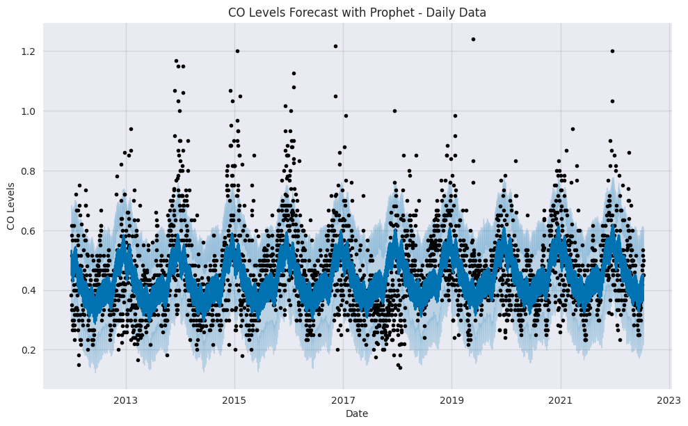

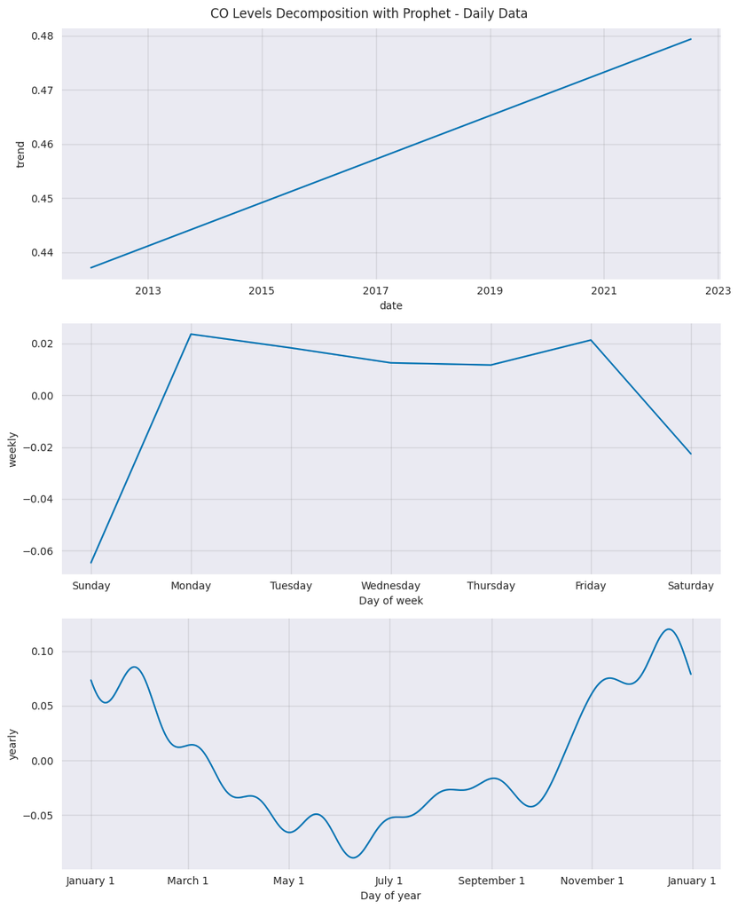

```python
model_prophet = Prophet(yearly_seasonality=True, weekly_seasonality=True,
                        daily_seasonality=False, changepoint_prior_scale=0.001,
                        changepoint_range=1.0)
model_prophet.fit(daily_train)

# Forecast for a number of periods equal to the length of the test set
forecast_prophet = model_prophet.predict()

# Calculate metrics for both models
prophet_fitted = forecast_prophet.loc[forecast_prophet['ds'].isin(prophet_df['ds']), 'yhat']
prophet_actual = prophet_df['y']


# Plot Prophet forecast and components
fig1 = model_prophet.plot(forecast_prophet)
plt.title('CO Levels Forecast with Prophet - Daily Data')
plt.xlabel('Date')
plt.ylabel('CO Levels')
# plt.savefig('prophet_daily_forecast_output.png', dpi = 300, bbox_inches='tight')

plt.show()

fig2 = model_prophet.plot_components(forecast_prophet, figsize=(10, 12))
fig2.axes[0].set_xlabel("date")
fig2.suptitle('CO Levels Decomposition with Prophet - Daily Data', x = 0.5, y = 1.01)
# plt.savefig('prophet_daily_components_output.png', dpi = 300, bbox_inches='tight')
plt.show()
```

### Preiction with Kalman Filters

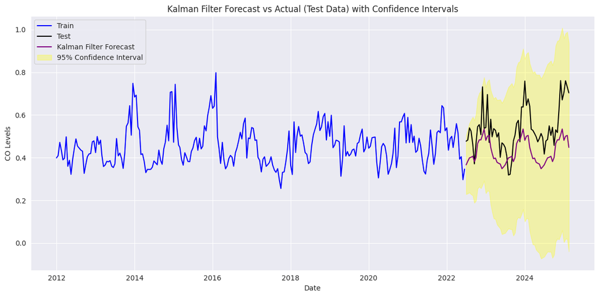

```
Kalman Filter Test RMSE: 0.13070595950284253
Kalman Filter Test MAE: 0.11402369410451686
```

```python
# Kalman Filter Forecast using Unobserved Components with Confidence Intervals
from statsmodels.tsa.statespace.structural import UnobservedComponents

# Fit the Unobserved Components Model with:
# - local level to capture the underlying state,
# - a seasonal component with a period of 24.
kalman_model = UnobservedComponents(train['CO'], level='local level', seasonal=24)
results_kalman = kalman_model.fit()

# Forecast over the test period (number of steps = len(test))
kalman_forecast = results_kalman.get_forecast(steps=len(test))
kalman_pred_test = kalman_forecast.predicted_mean

# Extract confidence intervals for the forecasts
kalman_conf_int = kalman_forecast.conf_int()

# Plot the training data, test data, Kalman filter forecasts, and confidence intervals
plt.figure(figsize=(12, 6))
plt.plot(train.index, train['CO'], label='Train', color='blue')
plt.plot(test.index, test['CO'], label='Test', color='black')
plt.plot(test.index, kalman_pred_test, label='Kalman Filter Forecast', color='purple')
plt.fill_between(
    test.index,
    kalman_conf_int.iloc[:, 0],  # lower bound
    kalman_conf_int.iloc[:, 1],  # upper bound
    color='yellow',
    alpha=0.3,
    label='95% Confidence Interval'
)
plt.title('Kalman Filter Forecast vs Actual (Test Data) with Confidence Intervals')
plt.xlabel('Date')
plt.ylabel('CO Levels')
plt.grid(True)
plt.tight_layout()
plt.legend()
# plt.savefig("kalman_forecast.png", dpi=300, bbox_inches = 'tight')
plt.show()

# Calculate error metrics for the Kalman filter forecast
kalman_rmse = np.sqrt(mean_squared_error(test['CO'], kalman_pred_test))
kalman_mae = mean_absolute_error(test['CO'], kalman_pred_test)

print("Kalman Filter Test RMSE:", kalman_rmse)
print("Kalman Filter Test MAE:", kalman_mae)
```

#### Rationale for Using a Kalman Filter (Unobserved Components Model)

1. **Dynamic State Estimation:**  
   It leverages the Kalman filter to dynamically update unobserved components such as the level (and trend, if needed) along with seasonal effects.
2. **Flexibility in Modeling Irregularities:**  
   This approach can better handle noise and changes in the underlying process since it estimates latent states over time.
3. **Seasonal Adjustment:**  
   Including a seasonal component (with a period of 24) allows the model to capture the seasonal patterns observed in the CO levels data.

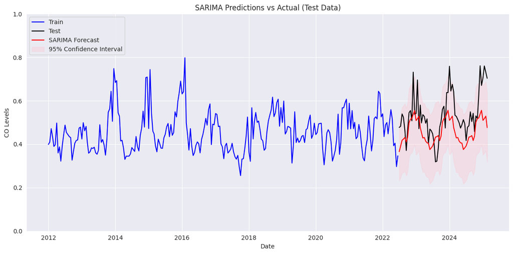

```python
# SARIMA Forecast on Test Data

# Forecast over the test period (number of steps = len(test))
n_test = len(test)
sarima_forecast_test = best_model['results'].get_forecast(steps=n_test)
sarima_pred_test = sarima_forecast_test.predicted_mean
sarima_conf_int_test = sarima_forecast_test.conf_int()

# Plot the training data, test data, and SARIMA forecasts with confidence intervals
plt.figure(figsize=(12, 6))
plt.plot(train.index, train['CO'], label='Train', color='blue')
plt.plot(test.index, test['CO'], label='Test', color='black')
plt.plot(test.index, sarima_pred_test, label='SARIMA Forecast', color='red')
plt.fill_between(test.index,
                 sarima_conf_int_test.iloc[:, 0],
                 sarima_conf_int_test.iloc[:, 1],
                 color='pink', alpha=0.3, label='95% Confidence Interval')
plt.title('SARIMA Predictions vs Actual (Test Data)')
plt.xlabel('Date')
plt.ylabel('CO Levels')
plt.ylim(0,1)
plt.grid(True)
plt.tight_layout()
plt.legend(loc='upper left')
# plt.savefig("sarima_forecast.png", dpi=300, bbox_inches = 'tight')
plt.show()
```

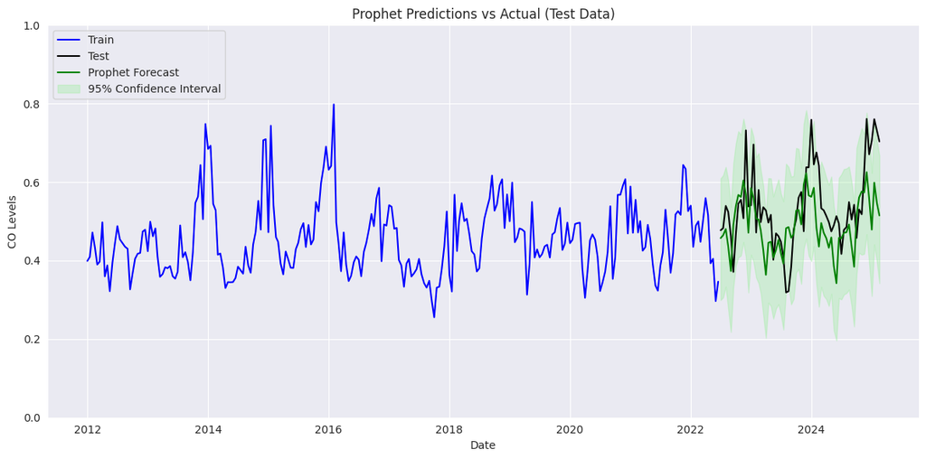

```python
# Prophet Forecast on Test Data (Updated with half-month intervals and index alignment)

# Generate a future dataframe with half-month intervals equal to the length of the test set
future_dates = model_prophet.make_future_dataframe(periods=len(test), freq='15D')
forecast_prophet = model_prophet.predict(future_dates)

# Instead of filtering by date, directly select the last len(test) rows
prophet_forecast_test = forecast_prophet.iloc[-len(test):].copy()

# Reassign the test index to the forecast for proper alignment
prophet_forecast_test.index = test.index

# Plot the training data, test data, and Prophet forecasts with confidence intervals
plt.figure(figsize=(12, 6))
plt.plot(train.index, train['CO'], label='Train', color='blue')
plt.plot(test.index, test['CO'], label='Test', color='black')
plt.plot(prophet_forecast_test.index, prophet_forecast_test['yhat'], label='Prophet Forecast', color='green')
plt.fill_between(prophet_forecast_test.index,
                 prophet_forecast_test['yhat_lower'],
                 prophet_forecast_test['yhat_upper'],
                 color='lightgreen', alpha=0.3, label='95% Confidence Interval')
plt.title('Prophet Predictions vs Actual (Test Data)')
plt.xlabel('Date')
plt.ylabel('CO Levels')
plt.legend(loc='upper left')
plt.ylim(0,1)
plt.grid(True)
# plt.savefig("prophet_forecast.png", dpi=300, bbox_inches = 'tight')
plt.tight_layout()
plt.show()
```

```python
from sklearn.metrics import mean_squared_error, mean_absolute_error
import numpy as np

# SARIMA test metrics (remains unchanged)
sarima_test_rmse = np.sqrt(mean_squared_error(test['CO'], sarima_pred_test))
sarima_test_mae = mean_absolute_error(test['CO'], sarima_pred_test)

# Prophet test metrics using the re-indexed forecast data
prophet_test_rmse = np.sqrt(mean_squared_error(test['CO'], prophet_forecast_test['yhat']))
prophet_test_mae = mean_absolute_error(test['CO'], prophet_forecast_test['yhat'])

# Kalman test metrics (using values from our Kalman filter forecast computed earlier)
kalman_test_rmse = kalman_rmse
kalman_test_mae = kalman_mae

print("SARIMA Test RMSE:", sarima_test_rmse)
print("SARIMA Test MAE:", sarima_test_mae)
print("Prophet Test RMSE:", prophet_test_rmse)
print("Prophet Test MAE:", prophet_test_mae)
print("Kalman Filter Test RMSE:", kalman_test_rmse)
print("Kalman Filter Test MAE:", kalman_test_mae)

# Compare models based on RMSE and choose the best one
model_errors = {
    'SARIMA': sarima_test_rmse,
    'Prophet': prophet_test_rmse,
    'Kalman': kalman_test_rmse
}

best_model = min(model_errors, key=model_errors.get)
print("\nBest model based on RMSE:", best_model)
```

```
SARIMA Test RMSE: 0.10939140425220269
SARIMA Test MAE: 0.09189455178257414
Prophet Test RMSE: 0.10024673784356021
Prophet Test MAE: 0.08023121144703427
Kalman Filter Test RMSE: 0.13070595950284253
Kalman Filter Test MAE: 0.11402369410451686

Best model based on RMSE: Prophet
```

### Model Performance Summary

**Best Model (based on RMSE): Prophet**

**Summary:**

Although Prophet demonstrates marginally better accuracy overall, with slightly lower RMSE and MAE values, all three approaches underestimate the actual CO levels, particularly near the final portion of the test set.

## Part 3 - Car Exogenous data

```python
from sklearn.preprocessing import MinMaxScaler
```

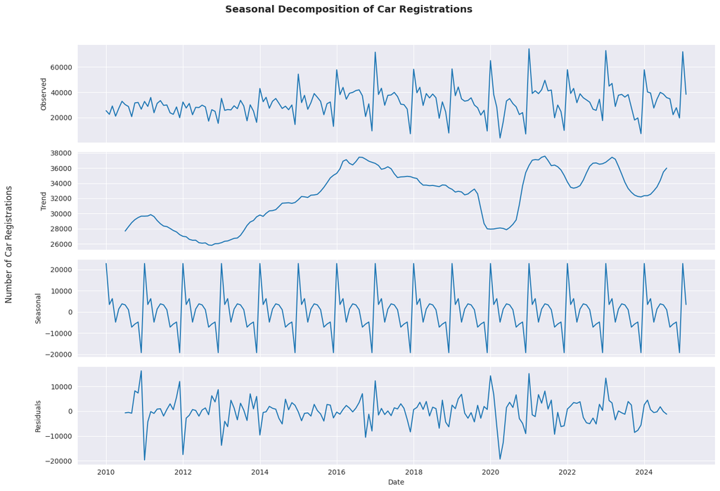

```python
# car monthly-series decomposition
def seasonal_analysis(df, duration):
    decomposition = seasonal_decompose(df["car_num"], period=duration, model='additive')

    fig, axes = plt.subplots(4, 1, figsize=(15, 10), sharex=True)
    fig.suptitle('Seasonal Decomposition of Car Registrations', fontsize=14, fontweight='bold')

    axes[0].plot(df["date"], df["car_num"])
    axes[0].set_ylabel("Observed")

    axes[1].plot(df["date"], decomposition.trend)
    axes[1].set_ylabel("Trend")

    axes[2].plot(df["date"], decomposition.seasonal)
    axes[2].set_ylabel("Seasonal")

    axes[3].plot(df["date"], decomposition.resid)
    axes[3].set_ylabel("Residuals")
    axes[3].set_xlabel("Date")

    # Add global y-axis label
    fig.text(0.04, 0.5, 'Number of Car Registrations', va='center', rotation='vertical', fontsize=12)

    plt.tight_layout(rect=[0.07, 0, 1, 0.95])  # Leave space for y-label and title
    # plt.savefig('visualizations/cars_registration_seasonal_decomposition.png')
    plt.show()

seasonal_analysis(cars.resample('MS').sum().reset_index(), 12)
```

```python
cars2012 = cars[cars.index >= '2012-01-01']
```

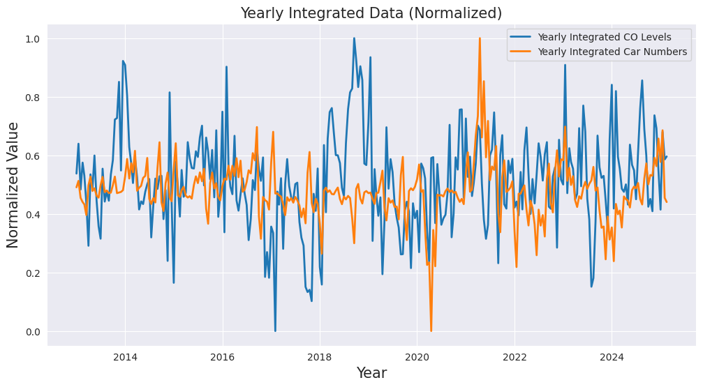

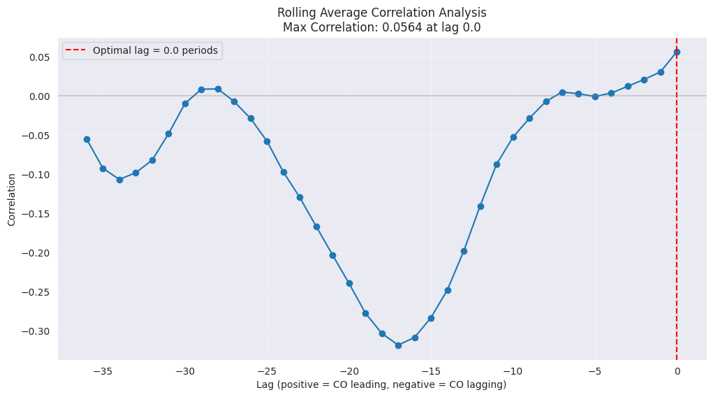

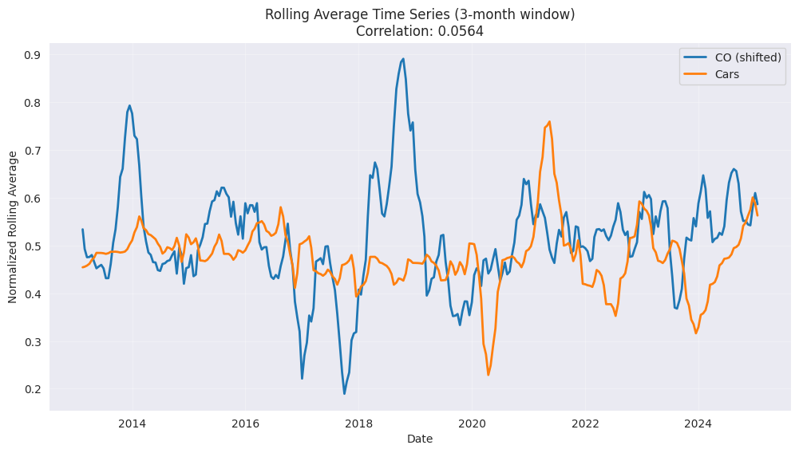

```
Rolling Average Analysis Summary:
Window size: 6 periods (3.0 months)
Optimal lag: 0.0 periods (0.0 months)
Maximum correlation: 0.0564
```

```python
yearly_integration_co = co_mean_2012.diff(periods=24).dropna()
yearly_integration_cars = cars2012.diff(periods=24).dropna()

# Ensure both series have the same index
common_index = yearly_integration_co.index.intersection(yearly_integration_cars.index)
yearly_integration_co = yearly_integration_co.loc[common_index]
yearly_integration_cars = yearly_integration_cars.loc[common_index]

# ---------------------
# 2. Normalize the Data (Scaling to [0, 1])
# ---------------------
scaler = MinMaxScaler()
yearly_integration_co_scaled = scaler.fit_transform(yearly_integration_co)
yearly_integration_cars_scaled = scaler.fit_transform(yearly_integration_cars)

# Create DataFrame with both series
combined_df = pd.DataFrame({
    'co': yearly_integration_co_scaled.flatten(),
    'cars': yearly_integration_cars_scaled.flatten()
}, index=common_index)

# Plot the normalized data
plt.figure(figsize=(12, 6))
plt.plot(yearly_integration_co.index, yearly_integration_co_scaled, label='Yearly Integrated CO Levels', linewidth=2)
plt.plot(yearly_integration_cars.index, yearly_integration_cars_scaled, label='Yearly Integrated Car Numbers', linewidth=2)
plt.title("Yearly Integrated Data (Normalized)", fontsize=15)
plt.xlabel('Year', fontsize=15)
plt.ylabel('Normalized Value', fontsize=15)
plt.legend()
plt.show()

# ---------------------
# 3. Apply Rolling Average Transformation
# ---------------------
window = 6  # 3 months of bi-monthly data
roll_co = combined_df['co'].rolling(window=window, center=True).mean().dropna()
roll_cars = combined_df['cars'].rolling(window=window, center=True).mean().dropna()

# ---------------------
# 4. Find Optimal Lag
# ---------------------
def find_max_correlation(series1, series2, max_lag=36):
    """Find maximum correlation and optimal lag"""
    lag_range = range(-max_lag, 1)
    correlations = []
    for lag in lag_range:
        if lag == 0:
            corr = series1.corr(series2)
        else:
            corr = series1.shift(lag).corr(series2)
        correlations.append((lag, corr, abs(corr)))

    corr_df = pd.DataFrame(correlations, columns=['lag', 'correlation', 'abs_correlation'])
    optimal_lag = corr_df.loc[corr_df['correlation'].idxmax()]
    return optimal_lag, corr_df

# Calculate optimal lag
optimal_lag, corr_df = find_max_correlation(roll_co, roll_cars)

# ---------------------
# 5. Visualize Results
# ---------------------
# Plot correlation analysis
plt.figure(figsize=(12, 6))
plt.plot(corr_df['lag'], corr_df['correlation'], marker='o')
plt.axvline(x=optimal_lag['lag'], color='red', linestyle='--',
           label=f"Optimal lag = {optimal_lag['lag']} periods")
plt.axhline(y=0, color='gray', linestyle='-', alpha=0.3)
plt.title(f'Rolling Average Correlation Analysis\nMax Correlation: {optimal_lag["correlation"]:.4f} at lag {optimal_lag["lag"]}')
plt.xlabel('Lag (positive = CO leading, negative = CO lagging)')
plt.ylabel('Correlation')
plt.grid(True, alpha=0.3)
plt.legend()
plt.show()

# Plot time series with optimal lag
plt.figure(figsize=(12, 6))
shifted_co = roll_co.shift(int(optimal_lag['lag']))
plt.plot(shifted_co.index, shifted_co, label='CO (shifted)', linewidth=2)
plt.plot(roll_cars.index, roll_cars, label='Cars', linewidth=2)
plt.title(f'Rolling Average Time Series (3-month window)\nCorrelation: {optimal_lag["correlation"]:.4f}')
plt.xlabel('Date')
plt.ylabel('Normalized Rolling Average')
plt.legend()
plt.grid(True, alpha=0.3)
plt.show()

# Print summary
print(f"\nRolling Average Analysis Summary:")
print(f"Window size: {window} periods ({window/2} months)")
print(f"Optimal lag: {optimal_lag['lag']} periods ({optimal_lag['lag']/2:.1f} months)")
print(f"Maximum correlation: {optimal_lag['correlation']:.4f}")
```

```
Train shape: (252, 1)
Test shape: (64, 1)

--- Prophet without exogenous variables ---
Prophet without exogenous variables - MSE: 0.0089, RMSE: 0.0944, MAE: 0.0792

--- Prophet with exogenous variables (cars) ---
Prophet with exogenous variables - MSE: 0.0089, RMSE: 0.0943, MAE: 0.0793

--- Performance Comparison ---
Performance improvement with exogenous variables: 0.19%
Average confidence interval width - Without exog: 0.1837, With exog: 0.1848
Confidence interval width reduction: -0.58%
```

| Metric | Prophet without Cars | Prophet with Cars | Improvement (%) |
| --- | --- | --- | --- |
| MSE | 0.0089 | 0.0089 | 0.19% |
| RMSE | 0.0944 | 0.0943 | 0.09% |
| MAE | 0.0792 | 0.0793 | -0.21% |
| CI Width | 0.1837 | 0.1848 | -0.58% |
| Training Size | 252 | 252 | - |
| Test Size | 64 | 64 | - |

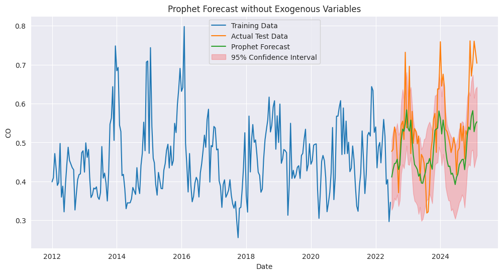

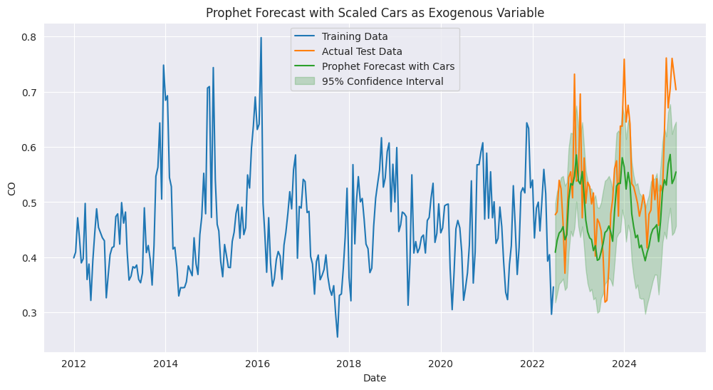

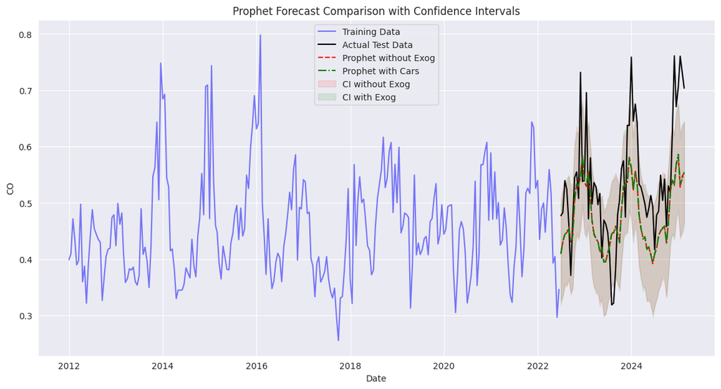

```python
# Fitting Prophet with Cars registration as exogenous variable

# Recalculate train/test split after alignment
train_size = int(len(co_mean_2012) * 0.8)
train = co_mean_2012.iloc[:train_size]
test = co_mean_2012.iloc[train_size:]

print("Train shape:", train.shape)
print("Test shape:", test.shape)

# Scale the exogenous data (car_num) using MinMaxScaler
scaler = MinMaxScaler()
dfCars_scaled = pd.DataFrame(
    scaler.fit_transform(cars2012),
    index=cars2012.index,
    columns=['car_num']
)

# Split the scaled cars data
train_cars_scaled = dfCars_scaled.iloc[:train_size]
test_cars_scaled = dfCars_scaled.iloc[train_size:]

# ---------------------
# 2. Prophet Implementation
# ---------------------

# Format data for Prophet (requires columns 'ds' for date and 'y' for target)
def prepare_prophet_data(df, exog=None):
    # Reset index to get Date as a column
    df_reset = df.reset_index()

    # Create a dataframe for Prophet
    df_prophet = pd.DataFrame()
    df_prophet['ds'] = df_reset['date']
    df_prophet['y'] = df_reset['CO']

    # Add exogenous variable if provided
    if exog is not None:
        exog_reset = exog.reset_index()
        df_prophet['cars'] = exog_reset['car_num']

    return df_prophet

# Without exogenous variables
print("\n--- Prophet without exogenous variables ---")
# Prepare training data
train_prophet = prepare_prophet_data(train)

# Create and fit the model
model_prophet = Prophet(yearly_seasonality=True, weekly_seasonality=False, daily_seasonality=False)
model_prophet.fit(train_prophet)

# Create a dataframe for future predictions that includes the test period
future = model_prophet.make_future_dataframe(periods=len(test), freq='15D')

# Generate predictions
forecast = model_prophet.predict(future)

# Extract predictions for the test period
predictions_prophet = forecast.iloc[-len(test):]['yhat'].values
# Extract confidence intervals
lower_bound = forecast.iloc[-len(test):]['yhat_lower'].values
upper_bound = forecast.iloc[-len(test):]['yhat_upper'].values

# Calculate performance metrics
mse_prophet = mean_squared_error(test['CO'].values, predictions_prophet)
rmse_prophet = np.sqrt(mse_prophet)
mae_prophet = mean_absolute_error(test['CO'].values, predictions_prophet)

print(f"Prophet without exogenous variables - MSE: {mse_prophet:.4f}, RMSE: {rmse_prophet:.4f}, MAE: {mae_prophet:.4f}")

# Plot results
plt.figure(figsize=(12, 6))
plt.plot(train.index, train['CO'], label='Training Data')
plt.plot(test.index, test['CO'], label='Actual Test Data')
plt.plot(test.index, predictions_prophet, label='Prophet Forecast')
# Add confidence intervals
plt.fill_between(test.index, lower_bound, upper_bound, color='red', alpha=0.2, label='95% Confidence Interval')
plt.title('Prophet Forecast without Exogenous Variables')
plt.xlabel('Date')
plt.ylabel('CO')
plt.legend()


# With exogenous variables (cars)
print("\n--- Prophet with exogenous variables (cars) ---")
# Prepare training data with scaled exogenous variable
train_prophet_exog = prepare_prophet_data(train, train_cars_scaled)

# Create and fit the model
model_prophet_exog = Prophet(yearly_seasonality=True, weekly_seasonality=False, daily_seasonality=False)
# Add regressor
model_prophet_exog.add_regressor('cars')
model_prophet_exog.fit(train_prophet_exog)

# Create a dataframe for future predictions
future_exog = model_prophet_exog.make_future_dataframe(periods=len(test), freq='15D')
# Add the scaled exogenous variable values for both training and test periods
future_cars = pd.concat([train_cars_scaled, test_cars_scaled])
future_exog['cars'] = future_cars['car_num'].values

# Generate predictions
forecast_exog = model_prophet_exog.predict(future_exog)

# Extract predictions for the test period
predictions_prophet_exog = forecast_exog.iloc[-len(test):]['yhat'].values
# Extract confidence intervals for the model with exogenous variables
lower_bound_exog = forecast_exog.iloc[-len(test):]['yhat_lower'].values
upper_bound_exog = forecast_exog.iloc[-len(test):]['yhat_upper'].values

# Calculate performance metrics
mse_prophet_exog = mean_squared_error(test['CO'].values, predictions_prophet_exog)
rmse_prophet_exog = np.sqrt(mse_prophet_exog)
mae_prophet_exog = mean_absolute_error(test['CO'].values, predictions_prophet_exog)

print(f"Prophet with exogenous variables - MSE: {mse_prophet_exog:.4f}, RMSE: {rmse_prophet_exog:.4f}, MAE: {mae_prophet_exog:.4f}")

# Plot results
plt.figure(figsize=(12, 6))
plt.plot(train.index, train['CO'], label='Training Data')
plt.plot(test.index, test['CO'], label='Actual Test Data')
plt.plot(test.index, predictions_prophet_exog, label='Prophet Forecast with Cars')
# Add confidence intervals
plt.fill_between(test.index, lower_bound_exog, upper_bound_exog, color='green', alpha=0.2, label='95% Confidence Interval')
plt.title('Prophet Forecast with Scaled Cars as Exogenous Variable')
plt.xlabel('Date')
plt.ylabel('CO')
plt.legend()


# Compare results
print("\n--- Performance Comparison ---")
improvement = ((mse_prophet - mse_prophet_exog) / mse_prophet) * 100
print(f"Performance improvement with exogenous variables: {improvement:.2f}%")
# Compare confidence interval widths
ci_width_without = np.mean(upper_bound - lower_bound)
ci_width_with = np.mean(upper_bound_exog - lower_bound_exog)
print(f"Average confidence interval width - Without exog: {ci_width_without:.4f}, With exog: {ci_width_with:.4f}")
print(f"Confidence interval width reduction: {((ci_width_without - ci_width_with) / ci_width_without) * 100:.2f}%")

# Create results comparison table
results_data = {
    'Metric': ['MSE', 'RMSE', 'MAE', 'CI Width', 'Training Size', 'Test Size'],
    'Prophet without Cars': [
        f"{mse_prophet:.4f}",
        f"{rmse_prophet:.4f}",
        f"{mae_prophet:.4f}",
        f"{ci_width_without:.4f}",
        len(train),
        len(test)
    ],
    'Prophet with Cars': [
        f"{mse_prophet_exog:.4f}",
        f"{rmse_prophet_exog:.4f}",
        f"{mae_prophet_exog:.4f}",
        f"{ci_width_with:.4f}",
        len(train),
        len(test)
    ],
    'Improvement (%)': [
        f"{((mse_prophet - mse_prophet_exog) / mse_prophet * 100):.2f}%",
        f"{((rmse_prophet - rmse_prophet_exog) / rmse_prophet * 100):.2f}%",
        f"{((mae_prophet - mae_prophet_exog) / mae_prophet * 100):.2f}%",
        f"{((ci_width_without - ci_width_with) / ci_width_without * 100):.2f}%",
        "-",
        "-"
    ]
}

results_df = pd.DataFrame(results_data)
results_df.set_index('Metric', inplace=True)

display(results_df)

# Plot comparison
plt.figure(figsize=(14, 7))
plt.plot(train.index, train['CO'], label='Training Data', color='blue', alpha=0.5)
plt.plot(test.index, test['CO'], label='Actual Test Data', color='black')
plt.plot(test.index, predictions_prophet, label='Prophet without Exog', color='red', linestyle='--')
plt.plot(test.index, predictions_prophet_exog, label='Prophet with Cars', color='green', linestyle='-.')
# Add confidence intervals for both models
plt.fill_between(test.index, lower_bound, upper_bound, color='red', alpha=0.1, label='CI without Exog')
plt.fill_between(test.index, lower_bound_exog, upper_bound_exog, color='green', alpha=0.1, label='CI with Exog')
plt.title('Prophet Forecast Comparison with Confidence Intervals')
plt.xlabel('Date')
plt.ylabel('CO')
plt.legend()
```

## Part 4 - Change-Point detection

```python
co_mean = (co_levels.groupby(co_levels.index)["CO"]
           .mean()
           .reset_index()
           .set_index('date'))
```

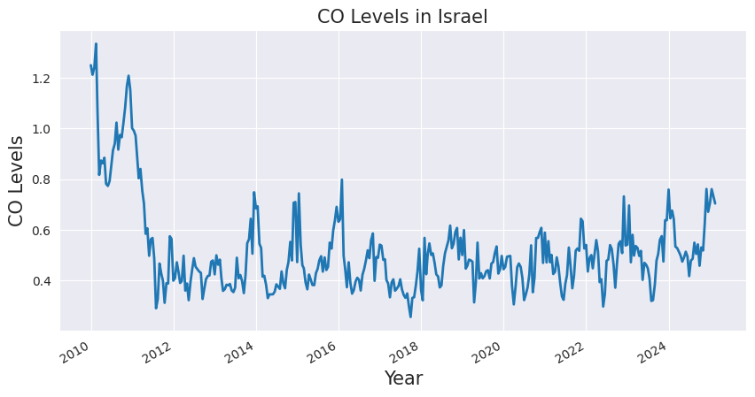

```python
co_mean.plot(figsize=(10,5), linewidth=2, fontsize=10)
plt.title("CO Levels in Israel",fontsize=15)
plt.xlabel('Year', fontsize=15)
plt.ylabel('CO Levels', fontsize=15)
plt.legend().set_visible(False)
plt.show()
```

```python
!pip install ruptures
```

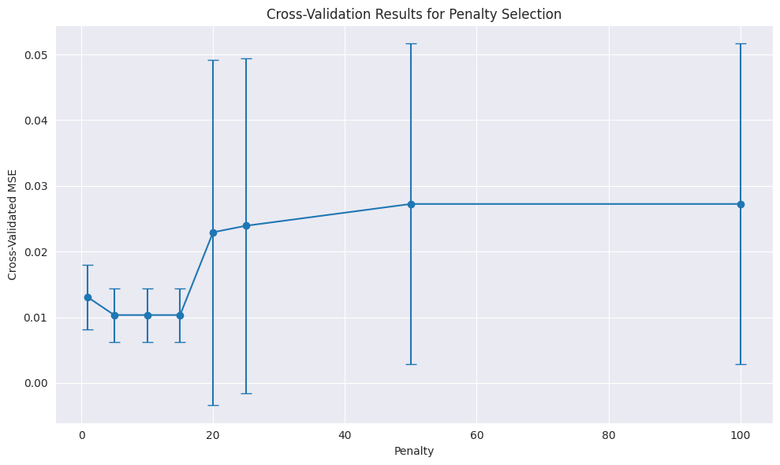

```
Best penalties based on MSE (within tolerance): [5, 10, 15]
Multiple penalties have similar MSE. Using BIC as tiebreaker...
```

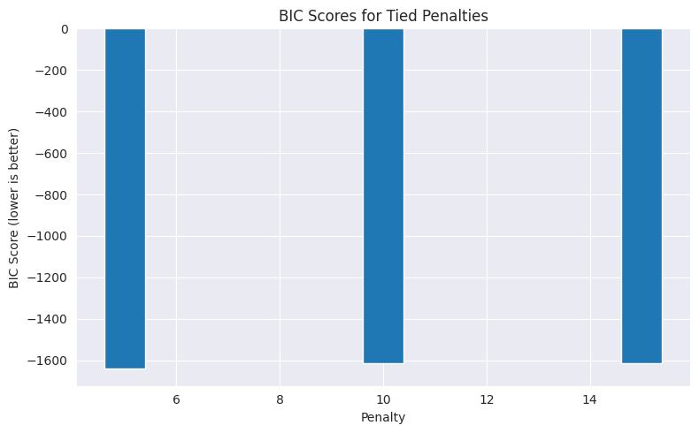

```
Optimal penalty based on BIC tiebreaker: 5
Change points detected with optimal penalty: [30, 195, 355, 364]
```

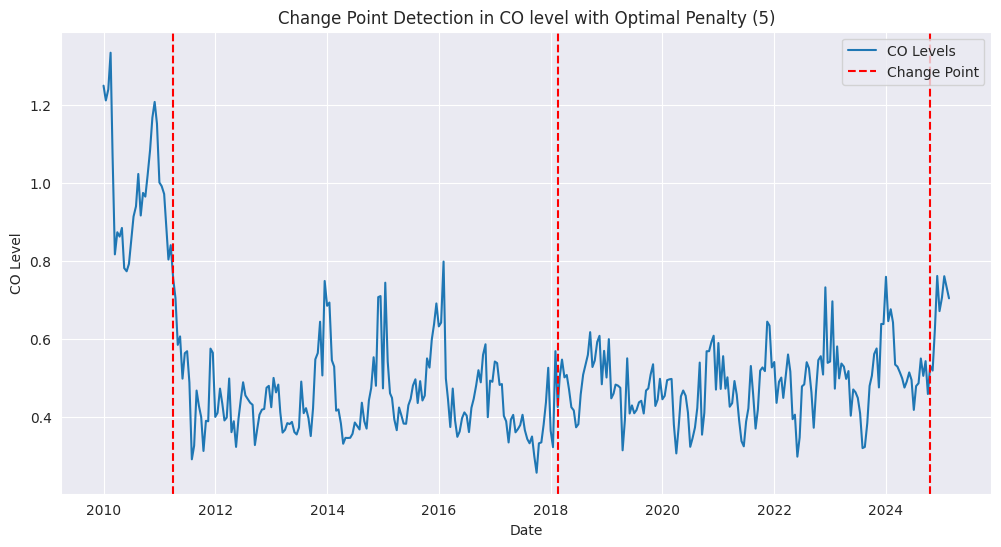

|  | Penalty | MSE | BIC | Num Change Points |
| --- | --- | --- | --- | --- |
| 0 | 1 | 0.0130 | -1763.3364 | 36 |
| 1 | 5 | 0.0103 | -1641.5177 | 4 |
| 2 | 10 | 0.0103 | -1612.6369 | 2 |
| 3 | 15 | 0.0103 | -1612.6369 | 2 |
| 4 | 20 | 0.0229 | -1612.6369 | 2 |
| 5 | 25 | 0.0239 | -1249.2973 | 1 |
| 6 | 50 | 0.0272 | -1249.2973 | 1 |
| 7 | 100 | 0.0272 | -1249.2973 | 1 |

```python
import ruptures as rpt
from sklearn.model_selection import TimeSeriesSplit

# Load data
signal = co_mean['CO'].values

# Define cross-validation function for MSE
def cv_penalty_selection(signal, penalty_range, n_splits=5):
    tscv = TimeSeriesSplit(n_splits=n_splits)
    cv_results = {penalty: [] for penalty in penalty_range}

    for train_index, test_index in tscv.split(signal):
        train_signal = signal[train_index]
        test_signal = signal[test_index]

        for penalty in penalty_range:
            algo = rpt.Pelt(model="rbf").fit(train_signal)
            change_pts = algo.predict(pen=penalty)

            reconstructed = np.zeros_like(test_signal)
            if len(change_pts) == 0:
                reconstructed[:] = np.mean(train_signal)
            else:
                segments = []
                for i in range(len(change_pts)):
                    if i == 0:
                        segment = train_signal[0:change_pts[i]]
                    else:
                        segment = train_signal[change_pts[i-1]:change_pts[i]]
                    segments.append(np.mean(segment))
                reconstructed[:] = segments[-1]

            mse = mean_squared_error(test_signal, reconstructed)
            cv_results[penalty].append(mse)

    avg_mse = {penalty: np.mean(scores) for penalty, scores in cv_results.items()}
    std_mse = {penalty: np.std(scores) for penalty, scores in cv_results.items()}

    return avg_mse, std_mse

# Define function to calculate BIC
def calculate_bic(signal, penalty):
    algo = rpt.Pelt(model="rbf").fit(signal)
    change_pts = algo.predict(pen=penalty)

    # Calculate segments and their means
    segments = []
    for i in range(len(change_pts)):
        if i == 0:
            segment = signal[0:change_pts[i]]
        else:
            segment = signal[change_pts[i-1]:change_pts[i]]
        segments.append(segment)

    # Calculate reconstruction error
    reconstructed = np.zeros_like(signal)
    idx = 0
    for segment in segments:
        segment_mean = np.mean(segment)
        segment_len = len(segment)
        reconstructed[idx:idx+segment_len] = segment_mean
        idx += segment_len

    # Calculate residuals
    residuals = signal - reconstructed
    rss = np.sum(residuals**2)

    # Calculate BIC: BIC = n*ln(RSS/n) + k*ln(n)
    n = len(signal)
    k = len(change_pts) + 1  # number of parameters (segments)
    bic = n * np.log(rss/n) + k * np.log(n)

    return bic, change_pts

# Define penalty range
penalty_range = [1, 5, 10, 15, 20, 25, 50, 100]

# Step 1: Find best penalties based on MSE
avg_mse, std_mse = cv_penalty_selection(signal, penalty_range, n_splits=5)

# Plot MSE results
plt.figure(figsize=(10, 6))
plt.errorbar(
    list(avg_mse.keys()),
    list(avg_mse.values()),
    yerr=list(std_mse.values()),
    fmt='o-', capsize=5
)
plt.xlabel('Penalty')
plt.ylabel('Cross-Validated MSE')
plt.title('Cross-Validation Results for Penalty Selection')
plt.grid(True)
plt.tight_layout()
plt.show()

# Identify the best MSE scores with some tolerance
best_mse = min(avg_mse.values())
tolerance = 0.001  # 0.1% tolerance
tied_penalties = [p for p, mse in avg_mse.items() if mse <= best_mse + tolerance]

print(f"Best penalties based on MSE (within tolerance): {tied_penalties}")

# Step 2: If there are ties, use BIC as tiebreaker
if len(tied_penalties) > 1:
    print("Multiple penalties have similar MSE. Using BIC as tiebreaker...")

    bic_scores = {}
    change_points = {}

    for penalty in tied_penalties:
        bic, cp = calculate_bic(signal, penalty)
        bic_scores[penalty] = bic
        change_points[penalty] = cp

    # Plot BIC for tied penalties
    plt.figure(figsize=(8, 5))
    plt.bar(list(bic_scores.keys()), list(bic_scores.values()))
    plt.xlabel('Penalty')
    plt.ylabel('BIC Score (lower is better)')
    plt.title('BIC Scores for Tied Penalties')
    plt.grid(True, axis='y')
    plt.tight_layout()
    plt.show()

    optimal_penalty = min(bic_scores, key=bic_scores.get)
    optimal_change_pts = change_points[optimal_penalty]

    print(f"Optimal penalty based on BIC tiebreaker: {optimal_penalty}")
else:
    optimal_penalty = tied_penalties[0]
    algo_optimal = rpt.Pelt(model="rbf").fit(signal)
    optimal_change_pts = algo_optimal.predict(pen=optimal_penalty)

    print(f"Single optimal penalty based on MSE: {optimal_penalty}")

print(f"Change points detected with optimal penalty: {optimal_change_pts}")

dates = co_mean.index

# Final visualization with optimal penalty
plt.figure(figsize=(12, 6))
plt.plot(dates, signal, label="CO Levels")
for cp in optimal_change_pts:
    if cp < len(signal):  # Ensure point is within data range
        plt.axvline(x=dates[cp], color="red", linestyle="--",
                   label="Change Point" if cp == optimal_change_pts[0] else "")
plt.title(f"Change Point Detection in CO level with Optimal Penalty ({optimal_penalty})")
plt.xlabel("Date")
plt.ylabel("CO Level")
plt.legend()
# plt.savefig("changepoint_detection.png", dpi=300, bbox_inches = 'tight')
plt.show()
# ===== ADDED CODE: Table of Penalty Values =====
# Create a comprehensive table of all penalty values and their metrics
results_table = []

# Calculate metrics for all penalties
for penalty in penalty_range:
    # Run PELT algorithm with this penalty
    algo = rpt.Pelt(model="rbf").fit(signal)
    change_pts = algo.predict(pen=penalty)

    # Filter out the problematic change point at index 365
    filtered_change_pts = [cp for cp in change_pts if cp != 365]

    # Calculate BIC with filtered change points
    bic, _ = calculate_bic(signal, penalty)

    # Get CV MSE value
    mse = avg_mse.get(penalty, np.nan)

    # Convert change points to dates (assuming bimonthly data from Jan 2010)
    cp_dates = []
    for cp in filtered_change_pts:
        if cp < len(signal):
            # Calculate approximate date (each point is half a month)
            months_from_start = cp // 2
            day = "01" if cp % 2 == 0 else "16"
            year = 2010 + (months_from_start // 12)
            month = (months_from_start % 12) + 1
            date_str = f"{year}-{month:02d}-{day}"
            cp_dates.append(f"{cp} ({date_str})")

    # Add to results
    results_table.append({
        'Penalty': penalty,
        'MSE': mse,
        'BIC': bic,
        'Num Change Points': len(filtered_change_pts),
        'Change Points': filtered_change_pts,
        'Change Point Dates': cp_dates
    })

# Convert to DataFrame for better display
results_df = pd.DataFrame(results_table)

# Format the table
pd.set_option('display.max_colwidth', None)
pd.set_option('display.precision', 4)



# Create a focused view of the key metrics
summary_df = results_df[['Penalty', 'MSE', 'BIC', 'Num Change Points']]
display(summary_df)
```